# Online Appendix E

Ambiguity attitudes and surprises

Authors

Affiliations

Aljoscha Minnich

Center for Earth System Research and Sustainability (CEN), University of Hamburg

Department of Economics, University of Hamburg

Hauke Roggenkamp

Institute of Behavioral Science and Technology, University of St. Gallen

Faculty of Economics & Social Sciences, Helmut-Schmidt-University

Andreas Lange

Center for Earth System Research and Sustainability (CEN), University of Hamburg

Department of Economics, University of Hamburg

Published

July 5, 2024

This document explains how to reproduce the analyses presented in Online Appendix E.

```r
if (!requireNamespace("groundhog", quietly = TRUE)) {
    install.packages("groundhog")
    library("groundhog")
}

pkgs <- c("magrittr", "data.table", "stringr", "lubridate", "knitr", "glue",
          "sandwich", "lmtest",
          "ggplot2", "ggpubr", "rstatix", "patchwork","sjPlot", "stargazer")

groundhog::groundhog.library(pkg = pkgs,
                             date = "2023-09-25")
```

# Read Data

```r
# data <- data.table::fread(file = "../data/processed/full.csv")
data <- readRDS(file="../data/processed/full.Rda")
```

```r
data[, communication := as.factor(communication)]
data[, communication := factor(communication, levels = c("point", "both","interval"))]
data[, stage := as.factor(stage)]
data[, stage := factor(stage, levels = c("1", "2"))]
```

# Subsets to fulfill the assumptions

```r
data<-subset(data,data$a!=1&data$E12>=data$E1 & data$E13>=data$E1 &   data$E12>=data$E2 & data$E23>=data$E2 & data$E23>=data$E3 & data$E13>=data$E3)
data<-subset(data,duplicated(data$participant.label)|duplicated(data$participant.label,fromLast = TRUE))
```

# Defining subjective probability measure

```r
data$m1<-data$E1/100
data$m2<-data$E2/100
data$m3<-data$E3/100
data$m12<-data$E12/100
data$m13<-data$E13/100
data$m23<-data$E23/100

data$p1<-(data$m1-data$m23)/6/(data$mc-data$ms)+0.5
data$p2<-(data$m2-data$m13)/6/(data$mc-data$ms)+0.5
data$p3<-(data$m3-data$m12)/6/(data$mc-data$ms)+0.5
```

# Figure OE.1, OE.2, OE.3

```r
plot_bars <- function(response = "p", surprise_sub = NA, limits = ylim(-0.05, 1.02)){

  if(response == "p1"| response =="p2"| response =="p3"){
      y_1 = 0.6
      y_2 = 0.4
    } else {
      y_1 = 1.4
      y_2 = 1
    }


  if(!is.na(surprise_sub)){
    # Plot bottom panels
    tmp <- data[surprise == surprise_sub]
    names(tmp)[names(tmp) == response] <- 'outcome'

    if(surprise_sub){
      title <- "Surprising Condition"
    } else {
      title <- "Confirming Condition"
    }

    test_stats_1 <- tmp %>%
      group_by(communication) %>%
      wilcox_test(formula = outcome ~ stage,
                  paired = T) %>%
      adjust_pvalue(method = "none") %>%
      add_significance(p.col = "p.adj",
                       cutpoints = c(0, 0.01, 0.05, 0.1, 1),
                       symbols = c( "***", "**", "*", "ns")) %>%
      as.data.table()


    test_stats_2 <- tmp %>%
      group_by(stage) %>%
      wilcox_test(formula = outcome ~ communication) %>%
      adjust_pvalue(method = "none") %>%
      add_significance(p.col = "p.adj",
                       cutpoints = c(0, 0.01, 0.05, 0.1, 1),
                       symbols = c( "***", "**", "*", "ns")) %>%
      as.data.table()
    test_stats_2 <- test_stats_2[stage == 2]

    plot_bottom <- ggplot(data = tmp,
           mapping = aes(x = as.factor(communication),
                         y = outcome)) +
        geom_bar(aes(fill = stage),
                 position = "dodge",
                 stat = "summary",
                 fun = "mean") +
      limits +
      scale_fill_manual(values=c("black", "gray")) +
      theme_classic() +
      stat_pvalue_manual(data = test_stats_2,
                         label = "{p} ({p.adj.signif})",
                         step.group.by = "stage",
                         tip.length = 0,
                         step.increase = 0.1,
                         y.position = y_1) +
      stat_pvalue_manual(data = test_stats_1,
                         label = "{p} ({p.adj.signif})",
                         y.position = y_2,
                         tip.length = 0,
                         x = "communication") +
      labs(title = title,
           x = "Communication",
           y = glue("{response}"))

    rm(tmp)

    plot_bottom
  } else {
    # Plot the top panel
    tmp <- data
    names(tmp)[names(tmp) == response] <- 'outcome'

    title <- "Both Conditions"

    test_stats_1 <- tmp %>%
      group_by(surprise) %>%
      wilcox_test(formula = outcome ~ stage,
                  paired = T) %>%
      adjust_pvalue(method = "none") %>%
      add_significance(p.col = "p.adj",
                       cutpoints = c(0, 0.01, 0.05, 0.1, 1),
                       symbols = c( "***", "**", "*", "ns")) %>%
      as.data.table()


    test_stats_2 <- tmp %>%
      group_by(stage) %>%
      wilcox_test(formula = outcome ~ surprise) %>%
      adjust_pvalue(method = "none") %>%
      add_significance(p.col = "p.adj",
                       cutpoints = c(0, 0.01, 0.05, 0.1, 1),
                       symbols = c( "***", "**", "*", "ns")) %>%
      as.data.table()
    test_stats_2 <- test_stats_2[stage == 2]


    plot_top <- ggplot(data = tmp,
           mapping = aes(x = as.factor(surprise),
                         y = outcome)) +
        geom_bar(aes(fill = stage),
                 position = "dodge",
                 stat = "summary",
                 fun = "mean") +
      limits +
      scale_fill_manual(values=c("black", "gray")) +
      theme_classic() +
      stat_pvalue_manual(data = test_stats_2,
                         label = "{p} ({p.adj.signif})",
                         step.group.by = "stage",
                         tip.length = 0,
                         step.increase = 0.1,
                         y.position = y_1) +
      stat_pvalue_manual(data = test_stats_1,
                         label = "{p} ({p.adj.signif})",
                         y.position = y_2,
                         tip.length = 0,
                         x = "surprise") +
      labs(title = title,
           x = " Surprising Condition",
           y = glue("{response}"))

    rm(tmp)

    plot_top
  }
}
```

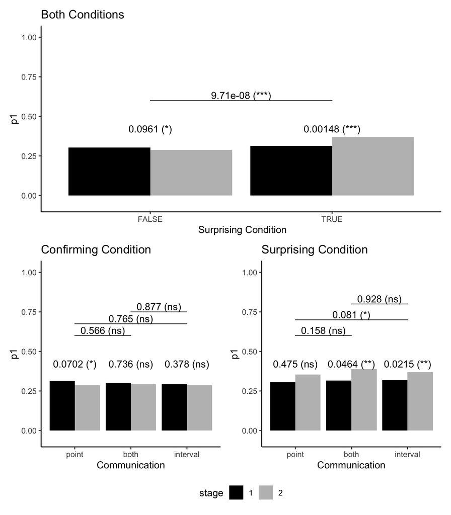

Figure 1: A-neutral probability $p_1$ separated by treatments and part 1 and part 2. P-values of Wilcoxon signed-rank test comparing part 1 and 2 directly above the mean values. P-values of Wilcoxon–Mann–Whitney test comparing part 2 of different treatments at the top. Note: $^{*}$p$<$0.10, $^{**}$p$<$0.05, $^{***}$p$<$0.01, ns: not significant

```r
top   <- plot_bars(response = "p1", surprise_sub = NA)
left  <- plot_bars(response = "p1", surprise_sub = FALSE)
right <- plot_bars(response = "p1", surprise_sub = TRUE)

(top / (left | right) & theme(legend.position = "bottom")) + plot_layout(guides = "collect")
```

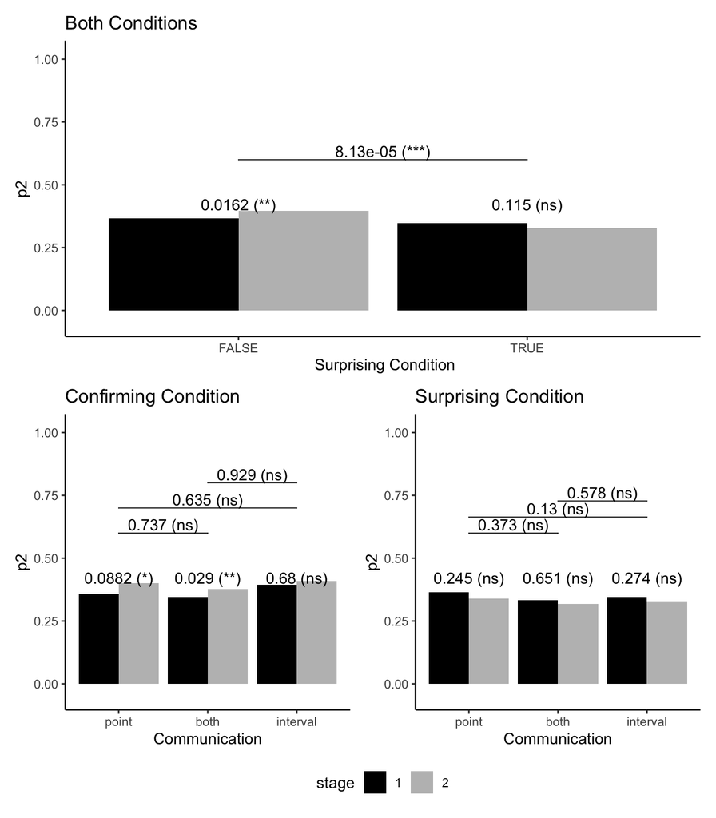

Figure 2: A-neutral probability $p_2$ separated by treatments and part 1 and part 2. P-values of Wilcoxon signed-rank test comparing part 1 and 2 directly above the mean values. P-values of Wilcoxon–Mann–Whitney test comparing part 2 of different treatments at the top. Note: $^{*}$p$<$0.10, $^{**}$p$<$0.05, $^{***}$p$<$0.01, ns: not significant

```r
top   <- plot_bars(response = "p2", surprise_sub = NA)
left  <- plot_bars(response = "p2", surprise_sub = FALSE)
right <- plot_bars(response = "p2", surprise_sub = TRUE)

(top / (left | right) & theme(legend.position = "bottom")) + plot_layout(guides = "collect")
```

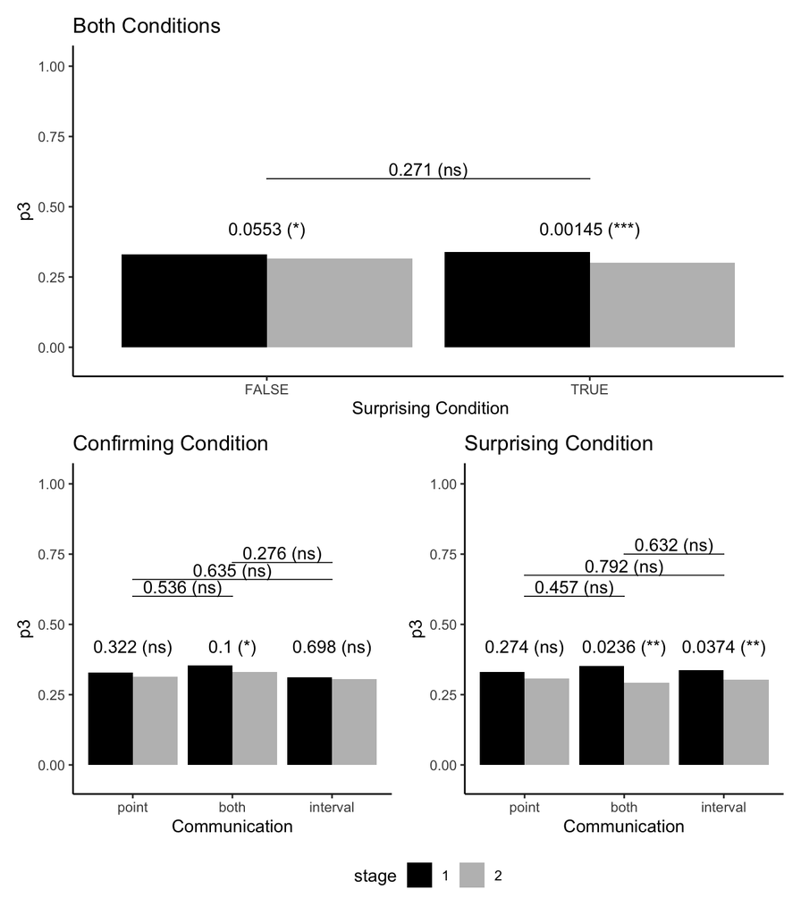

Figure 3: A-neutral probability $p_3$ separated by treatments and part 1 and part 2. P-values of Wilcoxon signed-rank test comparing part 1 and 2 directly above the mean values. P-values of Wilcoxon–Mann–Whitney test comparing part 2 of different treatments at the top. Note: $^{*}$p$<$0.10, $^{**}$p$<$0.05, $^{***}$p$<$0.01, ns: not significant

```r
top   <- plot_bars(response = "p3", surprise_sub = NA)
left  <- plot_bars(response = "p3", surprise_sub = FALSE)
right <- plot_bars(response = "p3", surprise_sub = TRUE)

(top / (left | right) & theme(legend.position = "bottom")) + plot_layout(guides = "collect")
```

# Regressions

```r
demographics <- c("age_35_52","age_53_plus","female", "high_education", "high_income", "married", "parentship")

all <- c(demographics, "high_temperature","high_usage","high_general_risk","high_weather_risk","high_accuracy","high_credibility")
```

```r
event_regressions <- function(event = "p1"){
  ols_1 <- lm(formula = reformulate(c("surprise", "treated", "surprise*treated"), response = event),
              data = data)
  se_1  <- coeftest(x = ols_1,
                    vcov = vcovCL(ols_1,
                                  cluster = ~data$participant.label,
                                  type = "HC1"))

  ols_2 <- lm(formula = reformulate(c("communication", "treated", "communication*treated"), response = event),
              data = data,
              subset = (surprise == FALSE))
  se_2  <- coeftest(x = ols_2,
                    vcov = vcovCL(ols_2,
                                  cluster = data[surprise == FALSE, participant.label],
                                  type = "HC1"))

  ols_3 <- lm(formula = reformulate(c("communication", "treated", "communication*treated"), response = event),
              data = data,
              subset = (surprise == TRUE))
  se_3  <- coeftest(x = ols_3,
                    vcov = vcovCL(ols_3,
                                  cluster = data[surprise == TRUE, participant.label],
                                  type = "HC1"))

  ols_4 <- lm(formula = reformulate(c("surprise", "treated", "surprise*treated"), response = event),
              data = data,
              subset = (communication == "point"))
  se_4  <- coeftest(x = ols_4,
                    vcov = vcovCL(ols_4,
                                  cluster = data[communication == "point", participant.label],
                                  type = "HC1"))

  ols_5 <- lm(formula = reformulate(c("surprise", "treated", "surprise*treated"), response = event),
              data = data,
              subset = (communication == "interval"))
  se_5  <- coeftest(x = ols_5,
                    vcov = vcovCL(ols_5,
                                  cluster = data[communication == "interval", participant.label],
                                  type = "HC1"))

  ols_6 <- lm(formula = reformulate(c("surprise", "treated", "surprise*treated"), response = event),
              data = data,
              subset = (communication == "both"))
  se_6  <- coeftest(x = ols_6,
                    vcov = vcovCL(ols_6,
                                  cluster = data[communication == "both", participant.label],
                                  type = "HC1"))



  se <- list(se_1[,2], se_2[,2], se_3[,2], se_4[,2], se_5[,2], se_6[,2])
  p  <- list(se_1[,4], se_2[,4], se_3[,4], se_4[,4], se_5[,4], se_6[,4])

  stargazer(ols_1, ols_2, ols_3, ols_4, ols_5, ols_6,
            align = TRUE,
            se = se,
            p = p,
            title = paste0("Linear regressions: Treatment effects on ", event),
            font.size = "scriptsize",
            type = "html",
            df = FALSE)
}
```

## p1

```r
event_regressions(event = "p1")
```

**Linear regressions: Treatment effects on p1**

|  | *Dependent variable:* |  |  |  |  |  |
| --- | --- | --- | --- | --- | --- | --- |
|  | c(“surprise”, “treated”, “surprise* treated”) | c(“communication”, “treated”, “communication* treated”) |  | c(“surprise”, “treated”, “surprise* treated”) |  |  |
|  | (1) | (2) | (3) | (4) | (5) | (6) |
| surprise | 0.010 |  |  | -0.009 | 0.024 | 0.014 |
|  | (0.011) |  |  | (0.019) | (0.019) | (0.019) |
| communicationboth |  | -0.012 | 0.011 |  |  |  |
|  |  | (0.019) | (0.018) |  |  |  |
| communicationinterval |  | -0.020 | 0.012 |  |  |  |
|  |  | (0.022) | (0.015) |  |  |  |
| treated | -0.014 | -0.026* | 0.049** | -0.026* | -0.008 | -0.009 |
|  | (0.009) | (0.015) | (0.023) | (0.015) | (0.016) | (0.016) |
| surpriseTRUE:treated | 0.071*** |  |  | 0.075*** | 0.059** | 0.082** |
|  | (0.017) |  |  | (0.028) | (0.026) | (0.033) |
| communicationboth:treated |  | 0.017 | 0.024 |  |  |  |
|  |  | (0.022) | (0.037) |  |  |  |
| communicationinterval:treated |  | 0.019 | 0.003 |  |  |  |
|  |  | (0.022) | (0.031) |  |  |  |
| Constant | 0.302*** | 0.313*** | 0.305*** | 0.313*** | 0.293*** | 0.302*** |
|  | (0.008) | (0.016) | (0.010) | (0.016) | (0.015) | (0.011) |
| Observations | 610 | 298 | 312 | 192 | 226 | 192 |
| R<sup>2</sup> | 0.074 | 0.008 | 0.066 | 0.050 | 0.082 | 0.100 |
| Adjusted R<sup>2</sup> | 0.070 | -0.009 | 0.050 | 0.035 | 0.069 | 0.086 |
| Residual Std. Error | 0.111 | 0.105 | 0.116 | 0.107 | 0.111 | 0.114 |
| F Statistic | 16.194*** | 0.474 | 4.299*** | 3.289** | 6.577*** | 6.971*** |
| *Note:* | *p<0.1; **p<0.05;*** p<0.01 |  |  |  |  |  |

## p2

```r
event_regressions(event = "p2")
```

**Linear regressions: Treatment effects on p2**

|  | *Dependent variable:* |  |  |  |  |  |
| --- | --- | --- | --- | --- | --- | --- |
|  | c(“surprise”, “treated”, “surprise* treated”) | c(“communication”, “treated”, “communication* treated”) |  | c(“surprise”, “treated”, “surprise* treated”) |  |  |
|  | (1) | (2) | (3) | (4) | (5) | (6) |
| surprise | -0.018 |  |  | 0.008 | -0.049** | -0.013 |
|  | (0.013) |  |  | (0.022) | (0.023) | (0.023) |
| communicationboth |  | -0.012 | -0.033 |  |  |  |
|  |  | (0.024) | (0.020) |  |  |  |
| communicationinterval |  | 0.038 | -0.019 |  |  |  |
|  |  | (0.026) | (0.017) |  |  |  |
| treated | 0.029** | 0.043* | -0.026 | 0.043* | 0.014 | 0.031 |
|  | (0.012) | (0.022) | (0.018) | (0.022) | (0.019) | (0.020) |
| surpriseTRUE:treated | -0.048*** |  |  | -0.068** | -0.032 | -0.045* |
|  | (0.015) |  |  | (0.029) | (0.022) | (0.026) |
| communicationboth:treated |  | -0.011 | 0.012 |  |  |  |
|  |  | (0.030) | (0.025) |  |  |  |
| communicationinterval:treated |  | -0.029 | 0.007 |  |  |  |
|  |  | (0.029) | (0.022) |  |  |  |
| Constant | 0.367*** | 0.357*** | 0.366*** | 0.357*** | 0.395*** | 0.345*** |
|  | (0.011) | (0.016) | (0.015) | (0.016) | (0.021) | (0.018) |
| Observations | 610 | 298 | 312 | 192 | 226 | 192 |
| R<sup>2</sup> | 0.039 | 0.024 | 0.029 | 0.030 | 0.070 | 0.035 |
| Adjusted R<sup>2</sup> | 0.034 | 0.007 | 0.013 | 0.014 | 0.057 | 0.019 |
| Residual Std. Error | 0.122 | 0.150 | 0.086 | 0.126 | 0.123 | 0.115 |
| F Statistic | 8.253*** | 1.405 | 1.796 | 1.913 | 5.550*** | 2.241* |
| *Note:* | *p<0.1; **p<0.05;*** p<0.01 |  |  |  |  |  |

## p3

```r
event_regressions(event = "p3")
```

**Linear regressions: Treatment effects on p3**

|  | *Dependent variable:* |  |  |  |  |  |
| --- | --- | --- | --- | --- | --- | --- |
|  | c(“surprise”, “treated”, “surprise* treated”) | c(“communication”, “treated”, “communication* treated”) |  | c(“surprise”, “treated”, “surprise* treated”) |  |  |
|  | (1) | (2) | (3) | (4) | (5) | (6) |
| surprise | 0.008 |  |  | 0.0004 | 0.025 | -0.002 |
|  | (0.010) |  |  | (0.017) | (0.016) | (0.017) |
| communicationboth |  | 0.024 | 0.022 |  |  |  |
|  |  | (0.017) | (0.017) |  |  |  |
| communicationinterval |  | -0.018 | 0.007 |  |  |  |
|  |  | (0.017) | (0.017) |  |  |  |
| treated | -0.015* | -0.016 | -0.023 | -0.016 | -0.006 | -0.022 |
|  | (0.008) | (0.015) | (0.018) | (0.015) | (0.015) | (0.013) |
| surpriseTRUE:treated | -0.023* |  |  | -0.006 | -0.027 | -0.037 |
|  | (0.014) |  |  | (0.023) | (0.023) | (0.025) |
| communicationboth:treated |  | -0.006 | -0.036 |  |  |  |
|  |  | (0.020) | (0.028) |  |  |  |
| communicationinterval:treated |  | 0.010 | -0.011 |  |  |  |
|  |  | (0.021) | (0.025) |  |  |  |
| Constant | 0.331*** | 0.329*** | 0.330*** | 0.329*** | 0.311*** | 0.353*** |
|  | (0.007) | (0.012) | (0.013) | (0.012) | (0.012) | (0.013) |
| Observations | 610 | 298 | 312 | 192 | 226 | 192 |
| R<sup>2</sup> | 0.023 | 0.029 | 0.045 | 0.012 | 0.020 | 0.064 |
| Adjusted R<sup>2</sup> | 0.019 | 0.012 | 0.030 | -0.004 | 0.007 | 0.049 |
| Residual Std. Error | 0.094 | 0.094 | 0.094 | 0.092 | 0.096 | 0.094 |
| F Statistic | 4.832*** | 1.740 | 2.902** | 0.740 | 1.512 | 4.304*** |
| *Note:* | *p<0.1; **p<0.05;*** p<0.01 |  |  |  |  |  |

# Figure OE.4

The corresponding data stems from many OLS regressions and are computed in for-loops. Even though the code differs slightly, it is very repetitive between the three panels, which is why we only explain the top panel

## Top Panel

Before calculating the data based on OLS regressions, we specify three different models: `none` represents only treatment variables, `demographics` extends the former by adding demographic variables, and `all` extends the former two by also adding all remaining covariates.

```r
none <- c("surprise", "treated", "surprise*treated")

demographics <- c(none, "age_35_52","age_53_plus","female", "high_education", "high_income", "married", "parentship")

all <- c(demographics, "high_temperature","high_usage","high_general_risk","high_weather_risk","high_accuracy","high_credibility")
```

Next, we run a nested loop that iterates through all three models and within these models through p1,p2,p3. From these ols regressions, we compute clustered standard errors using the `{{sandwich}}` and `{{lmtest}}` package. The resuling data is stored in a temporary data.table that is appended to an initially empty data.table called `ci_top`.

```r
ci_top <- data.table()
for(RHS in c("none", "demographics", "all")){
  for(LHS in c("p1", "p2","p3")){
    ols <- lm(formula = reformulate(termlabels = get(RHS),
                                    response = LHS),
              data = data)

    tmp <- coefci(x = ols,
                  parm = "surpriseTRUE:treatedTRUE",
                  vcov = vcovCL(x = ols,
                                cluster = data$participant.label,
                                type = "HC1"),
                  level = 0.95) %>%
      data.table(model = RHS, outcome = LHS)
    tmp[, center := (`2.5 %` + `97.5 %`)/2]

    ci_top <- rbind(ci_top, tmp)
  }
}
```

The result looks as follows. The data.table provides a column for the 2.5% and 97.5% confidence interval, the center of the two, as well as the ols specification as presented in `model` and `outcome`.

```r
ci_top %>% head(n = 7) %>% kable()
```

| 2.5 % | 97.5 % | model | outcome | center |
| --- | --- | --- | --- | --- |
| 0.0387231 | 0.1038418 | none | p1 | 0.0712824 |
| -0.0768856 | -0.0194949 | none | p2 | -0.0481902 |
| -0.0499375 | 0.0037531 | none | p3 | -0.0230922 |
| 0.0332199 | 0.1028268 | demographics | p1 | 0.0680234 |
| -0.0743612 | -0.0141922 | demographics | p2 | -0.0442767 |
| -0.0521607 | 0.0046673 | demographics | p3 | -0.0237467 |
| 0.0330266 | 0.1030202 | all | p1 | 0.0680234 |

Finally, we plot this data set (`ci_top`) using the `{{ggplot2}}` package. The resulting object is stored as `top` and will be assembled together with the other two panels.

```r
top <- ggplot(data = ci_top,
       mapping = aes(y = outcome)) +
  geom_pointrange(mapping = aes(x = center,
                                y = outcome,
                                xmin = `2.5 %`,
                                xmax = `97.5 %`,
                                shape = factor(model)),
                  data = ci_top,
                  position = position_dodge(width = 0.4),
                  fatten=5,
                  alpha=.8) +
   scale_y_discrete( limits=c("p3","p2", "p1"))+
  geom_vline(xintercept = 0,
             color = "red",
             alpha = 0.66,
             show.legend = FALSE) +
  theme_bw() +
  labs(#title = "(a) Effect of contradiction (relative to confirmation)",
       y = "Event",
       x = "Estimate",
       shape="Control variables")
```

## Left Panel

```r
none <- c("communication", "treated", "communication*treated")

demographics <- c(none, "age_35_52","age_53_plus","female", "high_education", "high_income", "married", "parentship")

all <- c(demographics, "high_temperature","high_usage","high_general_risk","high_weather_risk","high_accuracy","high_credibility")
```

```r
ci_left <- data.table()
for(RHS in c("none", "demographics", "all")){
  for(LHS in c("p1", "p2","p3")){
    ols <- lm(formula = reformulate(termlabels = get(RHS),
                                    response = LHS),
              data = data,
              subset = (surprise == FALSE))
    for(communication in c("interval", "both")){
      tmp <- coefci(x = ols,
                    parm = paste0("communication", communication, ":treatedTRUE"),
                    vcov = vcovCL(x = ols,
                                  cluster = data[surprise == FALSE,
                                                 participant.label],
                                  type = "HC1"),
                    level = 0.95) %>%
        data.table(model = RHS, outcome = paste0(LHS, " (", communication, ")"))
      tmp[, center := (`2.5 %` + `97.5 %`)/2]

      ci_left <- rbind(ci_left, tmp)
    }
  }
}
```

```r
ci_left %>% head(n = 7) %>% kable()
```

| 2.5 % | 97.5 % | model | outcome | center |
| --- | --- | --- | --- | --- |
| -0.0246024 | 0.0619968 | none | p1 (interval) | 0.0186972 |
| -0.0262891 | 0.0601811 | none | p1 (both) | 0.0169460 |
| -0.0865965 | 0.0288410 | none | p2 (interval) | -0.0288777 |
| -0.0702467 | 0.0480764 | none | p2 (both) | -0.0110851 |
| -0.0318660 | 0.0522271 | none | p3 (interval) | 0.0101806 |
| -0.0455580 | 0.0338363 | none | p3 (both) | -0.0058608 |
| -0.0308202 | 0.0622364 | demographics | p1 (interval) | 0.0157081 |

```r
left <- ggplot(data = ci_left,
       mapping = aes(y = outcome)) +
  geom_pointrange(mapping = aes(x = center,
                                y = outcome,
                                xmin = `2.5 %`,
                                xmax = `97.5 %`,
                                shape = factor(model)),
                  data = ci_left,
                  position = position_dodge(width = 0.4),
                  fatten=5,
                  alpha=.8) +
  scale_y_discrete( limits=c("p3 (interval)","p3 (both)","p2 (interval)","p2 (both)", "p1 (interval)","p1 (both)"))+
  geom_vline(xintercept = 0,
             color = "red",
             alpha = 0.66,
             show.legend = FALSE) +
  theme_bw() +
  labs(#title = "(b) Effect of information treatments (both, interval) relative to best guess, confirmation treatments",
       y = "Event",
       x = "Estimate",
       shape="Control variables")
```

## Right Panel

```r
ci_right <- data.table()
for(RHS in c("none", "demographics", "all")){
  for(LHS in c("p1", "p2","p3")){
    ols <- lm(formula = reformulate(termlabels = get(RHS),
                                    response = LHS),
              data = data,
              subset = (surprise == TRUE))
    for(communication in c("interval", "both")){
      tmp <- coefci(x = ols,
                    parm = paste0("communication", communication, ":treatedTRUE"),
                    vcov = vcovCL(x = ols,
                                  cluster = data[surprise == TRUE,
                                                 participant.label],
                                  type = "HC1"),
                    level = 0.95) %>%
        data.table(model = RHS, outcome = paste0(LHS, " (", communication, ")"))
      tmp[, center := (`2.5 %` + `97.5 %`)/2]

      ci_right <- rbind(ci_right, tmp)
    }
  }
}
```

```r
ci_right %>% head(n = 7) %>% kable()
```

| 2.5 % | 97.5 % | model | outcome | center |
| --- | --- | --- | --- | --- |
| -0.0581081 | 0.0648364 | none | p1 (interval) | 0.0033641 |
| -0.0488365 | 0.0971872 | none | p1 (both) | 0.0241754 |
| -0.0352094 | 0.0499602 | none | p2 (interval) | 0.0073754 |
| -0.0365894 | 0.0609859 | none | p2 (both) | 0.0121983 |
| -0.0596136 | 0.0381345 | none | p3 (interval) | -0.0107395 |
| -0.0909144 | 0.0181672 | none | p3 (both) | -0.0363736 |
| -0.0866100 | 0.0456250 | demographics | p1 (interval) | -0.0204925 |

```r
right <- ggplot(data = ci_right,
       mapping = aes(y = outcome)) +
  geom_pointrange(mapping = aes(x = center,
                                y = outcome,
                                xmin = `2.5 %`,
                                xmax = `97.5 %`,
                                shape = factor(model)),
                  data = ci_right,
                  position = position_dodge(width = 0.4),
                  fatten=5,
                  alpha=.8) +
  scale_y_discrete( limits=c("p3 (interval)","p3 (both)","p2 (interval)","p2 (both)", "p1 (interval)","p1 (both)"), position = "right")+
  geom_vline(xintercept = 0,
             color = "red",
             alpha = 0.66,
             show.legend = FALSE) +
  theme_bw() +
  labs(#title = "(c) Effect of information treatments (both, interval) relative to best guess, contradiction treatments",
       y = "Event",
       x = "Estimate",
       shape="Control variables")
```

## Assemble Top, Left and Right Panels

As before, we use the `{{patchwork}}` package to assmble the plot objects.

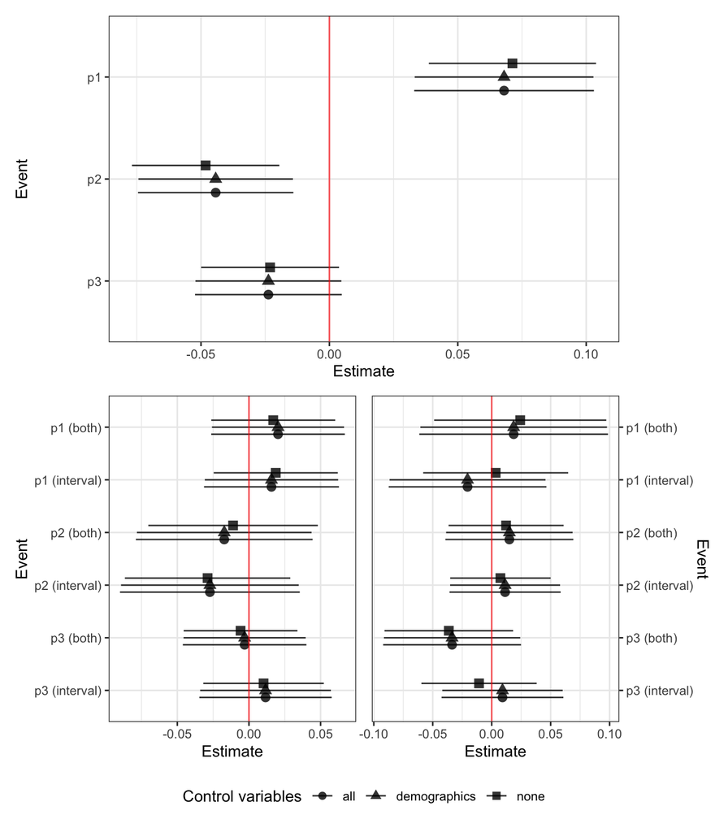

Figure 4: Treatment effects of regression equation (1) with dependent variables p1,p2,and p3. Estimators with 95% confidence intervals. The underlying standard errors (“HC1”) are clustered at the individual level and estimated with the R package sandwich (Zeileis, 2004; Zeileis et al., 2020).

```r
(top / (left | right) & theme(legend.position = "bottom")) + plot_layout(guides = "collect")
```

# Table OE.4

Calculating the Euclidian distance for the ambiguity neutral probabilities:

```r
ful1<-subset(data,data$stage==1)
ful2<-subset(data,data$stage==2)

cols <- c("participant.label", "p1","p2","p3")
ful1 <- ful1[, ..cols]
ful2 <- ful2[, ..cols]

ful<-merge(ful1,ful2,by="participant.label")
ful$ed<-sqrt((ful$p1.x-ful$p1.y)^2+(ful$p2.x-ful$p2.y)^2+(ful$p3.x-ful$p3.y)^2)
cols2 <- c("participant.label", "ed")
ful<-ful[, ..cols2]

data$ed<-NULL
data<-merge(data,ful,by="participant.label")
```

```r
ols_6_1 <- lm(formula = ed ~ surprise,
            data = data,
            subset = (stage == 2))
se_6_1  <- coeftest(ols_6_1, vcov = vcovHC(ols_6_1, type = "HC1"))

ols_6_2 <- lm(formula = ed ~ communication,
            data = data,
            subset = (stage == 2 & surprise == FALSE))
se_6_2  <- coeftest(ols_6_2, vcov = vcovHC(ols_6_2, type = "HC1"))

ols_6_3 <- lm(formula = ed ~ communication,
            data = data,
            subset = (stage == 2 & surprise == TRUE))
se_6_3  <- coeftest(ols_6_3, vcov = vcovHC(ols_6_3, type = "HC1"))

ols_6_4 <- lm(formula = ed ~ surprise,
            data = data,
            subset = (stage == 2 & communication == "point"))
se_6_4  <- coeftest(ols_6_4, vcov = vcovHC(ols_6_4, type = "HC1"))

ols_6_5 <- lm(formula = ed ~ surprise,
            data = data,
            subset = (stage == 2 & communication == "interval"))
se_6_5  <- coeftest(ols_6_5, vcov = vcovHC(ols_6_5, type = "HC1"))

ols_6_6 <- lm(formula = ed ~ surprise,
            data = data,
            subset = (stage == 2 & communication == "both"))
se_6_6  <- coeftest(ols_6_6, vcov = vcovHC(ols_6_6, type = "HC1"))
```

```r
se_6 <- list(se_6_1[,2], se_6_2[,2], se_6_3[,2], se_6_4[,2], se_6_5[,2], se_6_6[,2])
p_6  <- list(se_6_1[,4], se_6_2[,4], se_6_3[,4], se_6_4[,4], se_6_5[,4], se_6_6[,4])

stargazer(ols_6_1, ols_6_2, ols_6_3, ols_6_4, ols_6_5, ols_6_6,
          align = TRUE,
          se = se_6,
          p = p_6,
          title = "Linear regressions: Treatment effects on Euclidian distance between vector of matching probabilities in part 1 vs. part 2",
          font.size = "scriptsize",
          type = "html",
          df = FALSE)
```

**Linear regressions: Treatment effects on Euclidian distance between vector of matching probabilities in part 1 vs. part 2**

|  | *Dependent variable:* |  |  |  |  |  |
| --- | --- | --- | --- | --- | --- | --- |
|  | ed |  |  |  |  |  |
|  | (1) | (2) | (3) | (4) | (5) | (6) |
| surprise | 0.021 |  |  | 0.008 | 0.016 | 0.040 |
|  | (0.020) |  |  | (0.037) | (0.031) | (0.038) |
| communicationboth |  | 0.001 | 0.033 |  |  |  |
|  |  | (0.032) | (0.042) |  |  |  |
| communicationinterval |  | -0.0003 | 0.007 |  |  |  |
|  |  | (0.032) | (0.036) |  |  |  |
| Constant | 0.144*** | 0.143*** | 0.152*** | 0.143*** | 0.143*** | 0.145*** |
|  | (0.012) | (0.024) | (0.027) | (0.024) | (0.021) | (0.020) |
| Observations | 305 | 149 | 156 | 96 | 113 | 96 |
| R<sup>2</sup> | 0.003 | 0.00003 | 0.005 | 0.001 | 0.002 | 0.012 |
| Adjusted R<sup>2</sup> | 0.0002 | -0.014 | -0.008 | -0.010 | -0.007 | 0.001 |
| Residual Std. Error | 0.176 | 0.154 | 0.196 | 0.180 | 0.167 | 0.185 |
| F Statistic | 1.047 | 0.002 | 0.369 | 0.052 | 0.251 | 1.098 |
| *Note:* | *p<0.1; **p<0.05;*** p<0.01 |  |  |  |  |  |